# Entrega 3

Guillermo Coronado

26/5/2022

# **Introducción**

## Tema y justificación

La presente investigación aborda el tema de la calidad del empleo en el Perú. En específico, busca analizar el efecto de la edad y el nivel educativo de las personas en la calidad del empleo que estas obtienen. En este sentido, la pregunta que guiará este trabajo será la siguiente: ¿De qué manera el grupo etario y el nivel educativo influyen en la calidad del empleo que obtienen las personas en el Perú? La decisión de iinvestigar este tema proviene, por un lado, del interés que poseo por el estudio de temas relacionados al mundo laboral y a la desigualdad, pero, sobre todo, por el hecho de que, a mi consideración, este es un tema necesario a investigar en el Perú, ya que, como es bien sabido, uno de los retos que presenta el país es expandir el acceso al empleo de calidad.

## Revisión de literatura

En países como Estados Unidos y China, existe una literatura que analiza la relación entre el tipo de arreglo laboral de las personas y la calidad del empleo que poseen. En esta línea, Kalleberg, Reskin y Hudson (2000) muestran que, para el caso de Estados Unidos, los arreglos “no convencionales” (jornaleros, empleos conseguidos a través de agencias de trabajos temporales, trabajadores tercerizados, empleos temporales en empresas “convencionales”, contratación independiente y otras formas de autoempleo) incrementan la exposición de los trabajadores a “malos empleos” (con bajos salarios y sin acceso a seguro de salud ni sistema de pensiones) aun controlando por distintas variables demográficas y relacionadas a la educación. Por otro lado, Stainback y Tang (2019), analizan para el caso chino la relación entre el origen urbano o rural de los trabajadores y la probabilidad de tener un “mal empleo”, pero enfocándose en el papel que cumplen los arreglos laborales no convencionales como “mediadores” de esta situación. Los autores plantean tres modelos distintos que analizan la relación entre las tres variables y muestran que el hecho de que los trabajadores de origen rural sean más propensos a trabajar bajo un arreglo “no convencional” explica cerca del 50% del hecho de que estos sean a su vez más propensos a conseguir un mal empleo.

En el Perú, diversos economistas han estudiado el tema de la calidad del empleo, aunque, en su mayoría, centrándose en las llamadas “transiciones laborales”. Así, por ejemplo, Garavito (2010) analizó la vulnerabilidad en el empleo por género y etnicidad, entendiendo el término “vulnerabilidad” como el riesgo de una transición laboral que reduzca el bienestar del trabajador. Es decir, refiere al riesgo de caer en el desempleo o de obtener un empleo de menor calidad que el anterior. Al centrarse en transiciones, la autora utiliza datos de la ENAHO Panel para el periodo 2004-2006, y define la calidad del empleo a partir del ingreso proveniente del trabajo (si es menor o no a la remuneración mínima vital), la afiliación a un sistema de salud, y la posesión de un contrato de trabajo. En su análisis, la autora encontró que “las mujeres, los trabajadores indígenas, los jóvenes, los trabajadores mayores de 45 años, y aquellos con menor educación son los grupos con mayor probabilidad tanto de dejar la fuerza laboral como de ver reducida la calidad en su empleo” (Garavito, 2010, p.89). Rivarola (2018), por su parte, también se centra en las transiciones laborales, aunque realiza también un análisis “estático” sobre los determinantes de la calidad del empleo, encontrando que los jóvenes y las personas con menor educación son más propensos a tener empleos de mala calidad. En contraste con lo encontrado por Garavito, ni el sexo de la persona, ni su etnicidad (si se entiende esta como ligada a la lengua materna) son factores significativos. El tema de la juventud como factor de vulnerabilidad al momento de obtener empleo ha sido analizado de manera más específica. Franco y Ñopo (2018), por ejemplo, hallan que, si bien el desempleo juvenil no es una cuestión “preocupante”, sí lo son las altas tasas de subempleo y la falta de beneficios laborales en este grupo poblacional, en lo cual jugaría un papel importante la desigualdad en el acceso a la educación superior.

A partir de esta revisión, sostenemos como hipótesis que el hecho de ser joven (tener entre 14 y 24 años) y tener un nivel educativo menor a la educación superior completa aumenta la probabilidad de obtener un empleo de baja calidad.

## Modelo

Para realizar el análisis, proponemos el siguiente modelo:

$$Y_i = B_0 + B_1*G + B_2*I + B_3*S + B_4*T + B_5*C + B_6*M + B_7*H + B_8(T*I) + B_9(T * G) + ε$$

En donde:

- Y = Indicador de calidad del empleo. Toma valores del 0 al 3, siendo 3 un empleo de “máxima calidad”. Para construirlo, se tomaron en cuenta 3 variables
  - Ingreso: toma el valor de 1 si el trabajador percibe una remumeración mayor a la RMV.
  - Indicador de horas: toma el valor de 1 si el trabajador no está subempleado por horas (es decir, si no trabaja menos de 15 horas semanales al mismo tiempo que puede y desea trabajar más) y al mismo tiempo no trabaja más de 48 horas semanales.
  - Formalidad: toma el valor de 1 si la persona labora bajo un contrato de trabajo y/o si su negocio o actividad económica se encuentra registrada (ya sea como persona jurídica o natural, con lo que se abarcan también empresarios y trabajadores independientes).
- G = Grupo de edad de la persona. Los grupos van de 14 a 24 años, de 25 a 44 años, de 45 a 65 años, y de 66 años a más.
- I = Nivel educativo de la persona
- S = Sexo de la persona
- T = Tamaño de empresa en la que trabaja la persona. Se consideran los siguientes rangos: Hasta 20 personas, de 21 a 50 personas, de 51 a 100 personas, de 101 a 500 personas, y más de 500 personas
- C = Estado civil de la persona
- M = Lengua materna de la persona
- H = Rol en el hogar de la persona

Como señalamos, nos interesa hallar el efecto de la edad y el nivel educativo de las personas en la que calidad del empleo que obtuvieron, controlando por todas las otras variables incluidas en el modelo. Asimismo, estamos incluyendo en el modelo interacciones entre nuestras variables dependientes y la variable “tamaño de empresa”, ya que esperamos que, mientras más grande sea la empresa en la que se trabaja, el efecto negativo de ser joven y de tener un nivel educativo inferior al superior, disminuyan.

## Datos

Los datos que utilizaremos provienen de la Encuesta Nacional de Hogares (ENAHO) del año 2020. En específico, utilizaremos los módulos 2, 3 y 5, los cuales recogen información sobre las características de los miembros del hogar, educación, y empleo e ingresos, respectivamente. Dicho año la muestra fue de 37 103 viviendas y, por cada módulo, fue de 12 6831, 115 777, y 91 315 personas, respectivamente.

## Estadísticos descriptivos

```r
setwd("C:/Users/Lenovo/Desktop/kto/7/Estadística 2")
library(rio)
empleo_calid1 <- import("Base_final.Rda") #Importamos base ya trabajada
library(ggplot2)
library(ggthemes)
library(tidyverse)
library(kableExtra)
library(vcd)
library(vcdExtra)
```

Pasemos a presentar ahora la información descrpitiva de nuestra variable dependiente y de nuestras variables independientes. En primer lugar, el **Gráfico 1** nos muestra la distribución del puntaje de nuestro indicador de calidad de empleo. Recordemos que este puntaje va del 0 al 3, y contabiliza el número de características de un empleo “de calidad”.

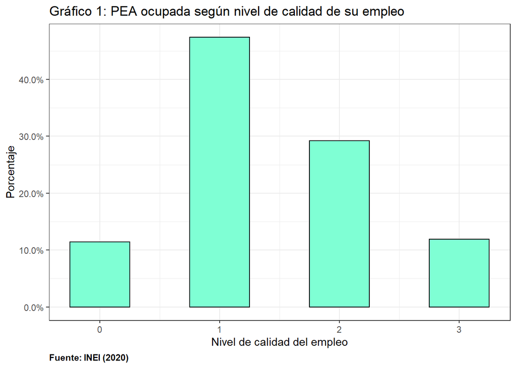

```r
Grafico1 <- ggplot(empleo_calid1, aes(x = calidad)) +
  geom_bar(aes(y = ..prop..),
           fill= "aquamarine",
           colour="black",
           width = 0.5) +
  scale_y_continuous(labels=scales::percent) +
  labs(x="Nivel de calidad del empleo",
       y="Porcentaje",
       title= "Gráfico 1: PEA ocupada según nivel de calidad de su empleo",
       caption = "Fuente: INEI (2020)") +
  theme_bw() +
  theme(plot.caption = element_text(hjust = 0,
                                    face = "bold"))
Grafico1
```

Como podemos observar en el mencionado gráfico, la mayoría de personas poseen tan solo un punto en nuestro indicador de calidad de emploe, seguidas, aunque de lejos, por aquellas que poseen dos. En contraste, la menor parte de la población se ubica en los extremos (los que tienen un trabajo sin ningún elemento “de calidad” o con todos los que consideramos).

Pasemos ahora a presentar nuestras variables independientes. El **Gráfico 2** muestra la distribución de nuestra muestra de acuerdo a sus edades. Vemos aquí que la mayoría de trabajadores tiene entre 25 y 44 años (35.33%), aunque el grupo más joven (de 14 a 24 años) y el grupo de personas de 45 a 65 años también incluyen a un porcentaje considerable de la población (ambos alrededor de un 28%). Por último, podemos ver que la población de adultos mayores de 65 años es la de menor número (tan solo un 7.71%).

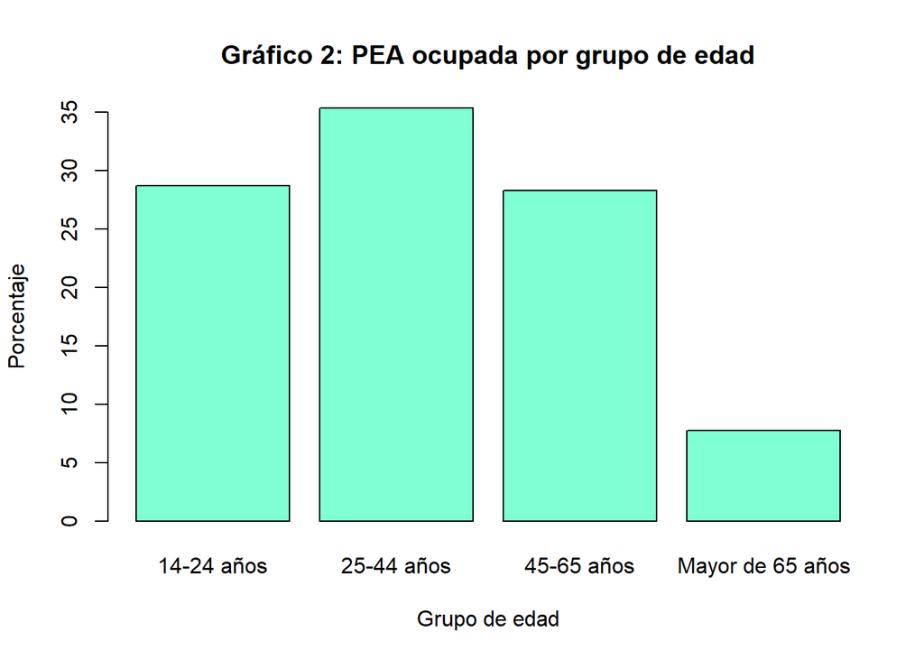

```r
Tabla <- prop.table(table(empleo_calid1$grupo_etario))*100
barplot(Tabla, main = "Gráfico 2: PEA ocupada por grupo de edad", xlab = "Grupo de edad",
        ylab = "Porcentaje", col = "aquamarine")
```

La **Tabla 1** nos muestra la distribución de la población ocupada de acuerdo a su máximo nivel educativo alcanzado. En ella podemos observar que un grupo mayoritario de la población (20.16%) llega como máximo a completar la secundaria, seguido de cerca por un 19.38% de personas que tienen primaria incompleta, y un 17.58% de personas con secundaria incompleta. Asimismo, las personas que poseen algún tipo de educación superior representan un porcentaje bastante bajo de la población: tan solo 5.72% de la PEA ocupada acabó la universidad, y 6.19% culminó algún tipo de educación superior no universitaria. Quienes poseen un posgrado, por su parte, representan un porcentaje menor aún (0.99%).

```r
tabla1 <- prop.table(table(empleo_calid1$Nivel_educa))*100

tabla1 %>%
  kable(digits = 2,
        caption = "Tabla 1: PEA ocupada según máximo nivel educativo alcanzado",
        format = "html",
        col.names = c("Nivel educativo", "Porcentaje")) %>%
  kable_classic("basic",full_width=F)
```

Tabla 1: PEA ocupada según máximo nivel educativo alcanzado

| Nivel educativo | Porcentaje |
| --- | --- |
| Sin nivel | 5.49 |
| Educación inicial | 4.50 |
| Primaria incompleta | 19.38 |
| Primaria completa | 10.79 |
| Secundaria incompleta | 17.58 |
| Secundaria completa | 20.16 |
| Superior no universitaria Incompleta | 3.63 |
| Superior no universitaria completa | 6.19 |
| Superior universitaria incompleta | 5.48 |
| Superior universitaria completa | 5.72 |
| Maestria / Doctorado | 0.99 |
| Básica especial | 0.11 |

El **Gráfico 3** nos permite comparar la calidad del empleo según los distintos grupos de edad. Como podemos observar, en todos los grupos la mayoría de la población tiene un puntaje de 1 en nuestro índice, sin embargo, este porcentaje va decayendo conforme aumenta la edad. Así, mientras cerca del 51% de jóvenes de 14 a 24 años tienen este puntaje, en el caso de los mayores de 65 años este porcentaje cae a 38.22%. Por otro lado, el porcentaje de personas con los empleos de más alta calidad (3 puntos) aumenta ligeramente conforme aumenta la edad, siendo, por ejemplo, un 10.13% de jóvenes de 12 a 24 años quienes poseen esta puntuación, y un 16.38% de mayores de 65 años que poseen estos empleos. La prueba de X^2 confirma que existe asociación entre ambas variables (X^2 = 36.41, p = 3.353e-05) y que esta asociación es positiva, es decir, que la calidad del empleo aumenta a medida que aumenta la edad de un grupo. No obstante, por el momento observamos que es una relación débil (gamma = 0.067). Por último, si bien se podría haber pensado que la calidad del empleo vuelve a disminuir entre los mayores de 65 años, a simple vista no se observa ello, ya que, si bien el porcentaje de personas con un puntaje de 0 en nuestro indicador aumenta muy ligeramente (alrededor de 2% respecto al grupo de edad anterior), el porcentaje de personas con un puntaje de 1, como vimos, dosminuye de manera más pronunciada, al mismo tiempo que aumenta el porcentaje de personas con un puntaje de 3.

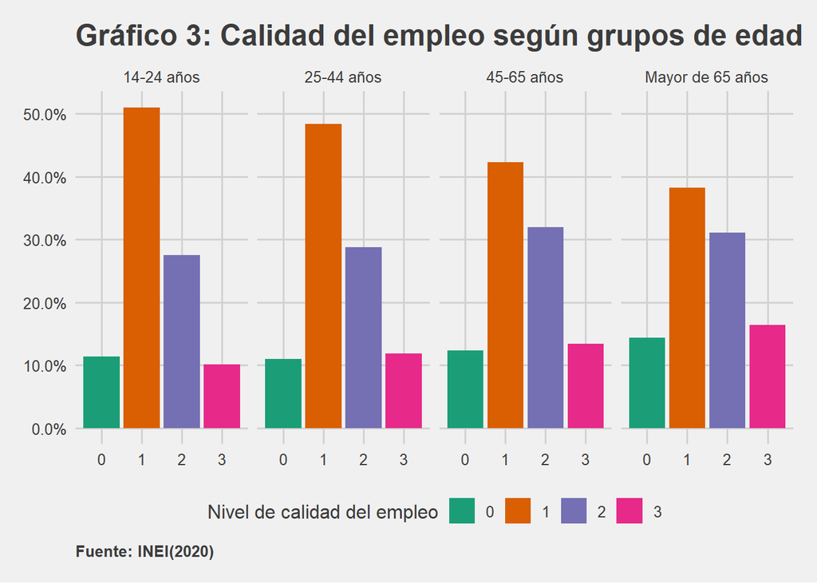

```r
Grafico3 <- empleo_calid1 %>%
  drop_na(calidad, grupo_etario) %>%
  ggplot(aes(calidad, group = grupo_etario)) +
  geom_bar(aes(y = ..prop.., fill = factor(..x..)), stat="count") +
  facet_grid(~grupo_etario) +
  scale_y_continuous(labels=scales::percent) +
  labs(x="Calidad del empleo", y="Porcentaje",
       fill="Nivel de calidad del empleo", title="Gráfico 3: Calidad del empleo según grupos de edad",
       caption = "Fuente: INEI(2020)") +
  scale_fill_brewer(palette= "Dark2") +
  theme_fivethirtyeight() +
  theme(plot.caption = element_text(hjust = 0,
                                    face = "bold"))
Grafico3
```

```r
tablaedad <- table(empleo_calid1$grupo_etario, empleo_calid1$calidad)
chisq.test(tablaedad)
```

```
##
##  Pearson's Chi-squared test
##
## data:  tablaedad
## X-squared = 36.41, df = 9, p-value = 3.353e-05
```

```r
GKgamma(tablaedad)
```

```
## gamma        : 0.067
## std. error   : 0.019
## CI           : 0.03 0.104
```

Por último, la **Tabla 2** nos muestra la calidad de los empleos de las personas de acuerdo a su nivel educativo. En esta, podemos ver de manera relativamente clara que, a medida que aumenta el nivel educativo de las personas, aumenta también la calidad de sus empleos. Así, por ejemplo, observamos que nadie que tiene educación universitaria completa posee un empleo con un puntaje de 0 en nuestro indice de calidad, lo cual contrasta con quienes tienen, por ejemplo, solo educación inicial completa, entre quienes el porcentaje de personas que poseen un empleo de estas características llega a 15.23%. Si nos vamos al extremo opuesto, vemos por ejemplo que un 40.58% de quienes terminaron la universidad posee un empleo con un puntaje de 3 en nuestro indice, en contraste con el 4.57% de personas con educación inicial que posen un empleo de estas características. En cuanto a los empleos con un puntaje de 1 punto, observamos que el porcentaje de personas que los posee tiende a disminuir conforme aumenta su nivel educativo, mientras que, en el caso de los empleos con un puntaje de 2 en nuestro indice, el porcentaje de personas que los posee más bien aumenta conforme aumenta su nivel educativo, hasta llegar a los niveles más altos (universidad completa y posgrados), donde este porcentaje vuelve a disminuir (ya que en su mayoría estas personas poseen un empleo con un puntaje de 3 en nuestro índice). La prueba de X^2 nos muestra que existe asociación en estas dos variables (X^2 = 747.92, p < 2.2e-16) y, además, podemos decir que esta asociación es positiva (aumenta la calidad del empleo a la par que aumenta el nivel educativo de las personas) y de una intensidad mayor que en el caso de la edad (gamma = 0.311).

```r
tabla2 <- prop.table(table(empleo_calid1$Nivel_educa, empleo_calid1$calidad),1)*100
tabla2 %>%
  kable(digits = 2,
        caption = "Tabla 2: Calidad de empleo según nivel educativo",
        format = "html") %>%
  add_header_above(c("Nivel educativo" = 1, "Calidad de empleo" = 4)) %>%
  kable_classic("basic",full_width=F)
```

Tabla 2: Calidad de empleo según nivel educativo

| Nivel educativo | Calidad de empleo 0 | Calidad de empleo 1 | Calidad de empleo 2 | Calidad de empleo 3 |
| --- | --- | --- | --- | --- |
| Sin nivel | 14.81 | 57.41 | 18.98 | 8.80 |
| Educación inicial | 15.23 | 51.78 | 28.43 | 4.57 |
| Primaria incompleta | 12.07 | 61.45 | 21.55 | 4.93 |
| Primaria completa | 12.53 | 52.74 | 28.72 | 6.01 |
| Secundaria incompleta | 15.72 | 54.03 | 23.78 | 6.47 |
| Secundaria completa | 13.29 | 49.19 | 27.74 | 9.78 |
| Superior no universitaria Incompleta | 10.00 | 27.27 | 43.64 | 19.09 |
| Superior no universitaria completa | 6.57 | 26.99 | 51.21 | 15.22 |
| Superior universitaria incompleta | 5.39 | 42.22 | 30.24 | 22.16 |
| Superior universitaria completa | 0.00 | 16.56 | 42.86 | 40.58 |
| Maestria / Doctorado | 0.00 | 15.22 | 39.13 | 45.65 |
| Básica especial | 0.00 | 0.00 | 100.00 | 0.00 |

```r
tablaeduca <- table(empleo_calid1$Nivel_educa, empleo_calid1$calidad)
chisq.test(tablaeduca)
```

```
##
##  Pearson's Chi-squared test
##
## data:  tablaeduca
## X-squared = 747.92, df = 33, p-value < 2.2e-16
```

```r
GKgamma(tablaeduca)
```

```
## gamma        : 0.311
## std. error   : 0.015
## CI           : 0.282 0.34
```

## Bibliografía

Garavito, C. (2010). Vulnerabilidad en el empleo: género y etnicidad en el Perú. *Economía*, 33(66), 89-127.

Kalleberg, A. L., Reskin, B. F., & Hudson, K. (2000). Bad jobs in America: Standard and nonstandard employment relations and job quality in the United States. *American sociological review*, 256-278.

Franco, A. P., & Ñopo, H. (2018). *Ser joven en el Perú: educación y trabajo*. Lima: GRADE

Rivarola, R. (2018). *Dinámica del mercado laboral en el Perú urbano. Un análisis desde la calidad del empleo en los trabajadores dependientes* [Tesis de licenciatura, Pontificia Universidad Católica del Perú]. http://hdl.handle.net/20.500.12404/15381

Stainback, K., & Tang, Z. (2019). Between state and market: Hukou, nonstandard employment, and bad jobs in urban China. *Chinese Sociological Review*, 51(3), 271-310.